# Health Costs Solution

www.PredictiveInsightsAI.com Practice Exam

12 June, 2021

For your convenience, this solution document has been formatted to be easy to read. When taking this exam, candidates are not expected to make their `.Rmd` documents look this way. The `make_table` function is included only to improve your reading experience. The SOA’s instructions from the Project Statement say only that

> At a minimum you must submit your completed report template and an Rmd file that supports your work. Graders expect that your Rmd code can be run from beginning to end. The code snippets provided should either be commented out or adapted for execution. Ensure that it is clear where in the code each of the tasks is addressed. Documentation of your thought process and conclusion for each task should be completely contained within your Word report. The Rmd code should be clear, may contain commentary, and support your work.

### Task 1 - Write a high-level summary of the data

```r
#Set up
#No changes needed to this code chunk

#set up
library(tidyverse)
library(ExamPAData)
library(gbm)
library(caret)
library(kableExtra)

#function to create html tables
make_table <- function(df, caption = ""){
  df %>%
    kable(caption = caption) %>%
    kable_styling(bootstrap_options = "striped", full_width = F)}

#global chunk options
knitr::opts_chunk$set(warning = F, message = F, echo = T, fig.width = 14, fig.height = 8, dev.args = list(type = "cairo"))

theme_set(theme_bw())
set.seed(1234)

#set factor levels to those with the most observations
health_insurance <- health_insurance %>%
  mutate(sex = fct_infreq(sex),
         smoker = fct_infreq(smoker),
         region = fct_infreq(region),
         )
```

```r
#start here
health_insurance %>% glimpse()
```

```
## Rows: 1,338
## Columns: 7
## $ age      <dbl> 19, 18, 28, 33, 32, 31, 46, 37, 37, 60, 25, 62, 23, 56, 27, 1~
## $ sex      <fct> female, male, male, male, male, female, female, female, male,~
## $ bmi      <dbl> 27.900, 33.770, 33.000, 22.705, 28.880, 25.740, 33.440, 27.74~
## $ children <dbl> 0, 1, 3, 0, 0, 0, 1, 3, 2, 0, 0, 0, 0, 0, 0, 1, 1, 0, 0, 0, 0~
## $ smoker   <fct> yes, no, no, no, no, no, no, no, no, no, no, yes, no, no, yes~
## $ region   <fct> southwest, southeast, southeast, northwest, northwest, southe~
## $ charges  <dbl> 16884.924, 1725.552, 4449.462, 21984.471, 3866.855, 3756.622,~
```

```r
#Can also use
#summary(health_insurance)
#str(health_insurance)
```

### Task 2 - Explore the target variables CHARGES and its relationship with SMOKER and BMI

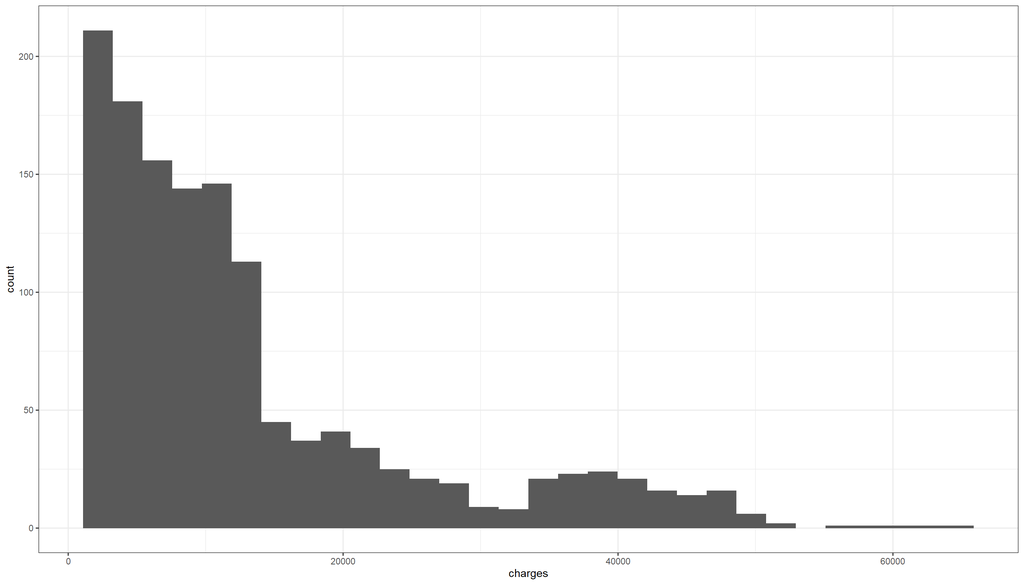

```r
health_insurance %>%
  ggplot(aes(charges)) +
  geom_histogram()
```

```r
health_insurance$charges %>% summary()
```

```
##    Min. 1st Qu.  Median    Mean 3rd Qu.    Max.
##    1122    4740    9382   13270   16640   63770
```

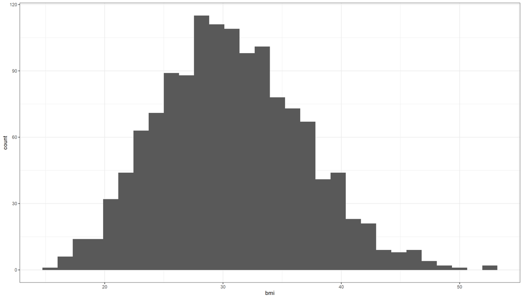

```r
health_insurance %>% ggplot(aes(bmi)) + geom_histogram()
```

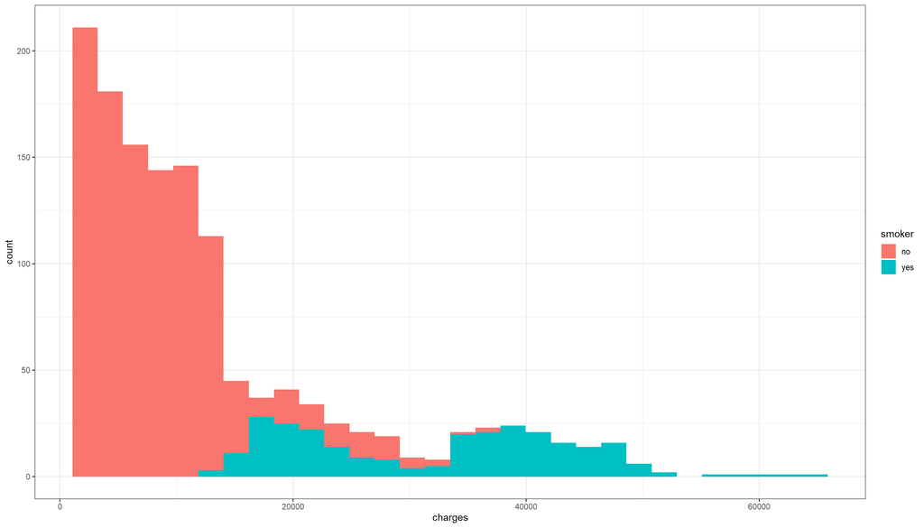

```r
health_insurance %>%
  ggplot(aes(charges, fill = smoker)) +
  geom_histogram()
```

```r
health_insurance %>%
  group_by(smoker) %>%
  summarise(mean = mean(charges),
            median = median(charges)) %>%
  make_table()
```

| smoker | mean | median |
| --- | --- | --- |
| no | 8434.268 | 7345.405 |
| yes | 32050.232 | 34456.348 |

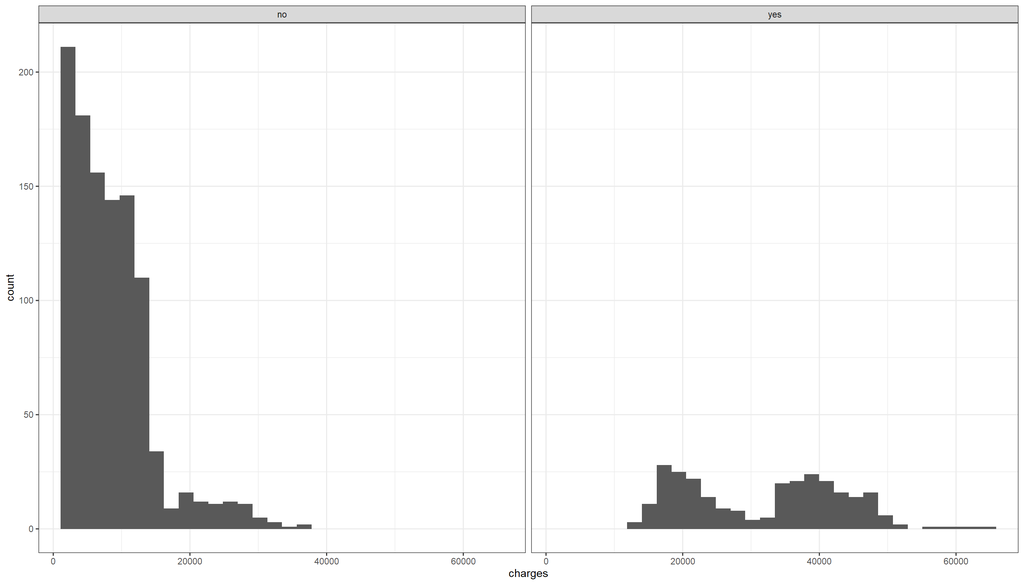

```r
health_insurance %>%
  ggplot(aes(charges)) +
  geom_histogram() +
  facet_wrap(vars(smoker))
```

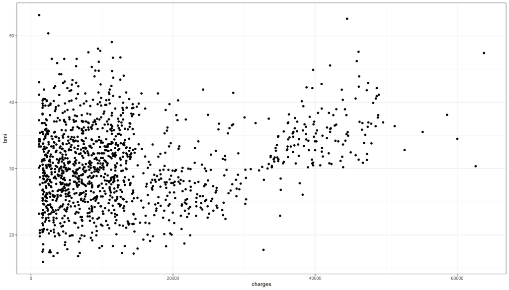

```r
health_insurance %>%
  ggplot(aes(charges, bmi)) +
  geom_point()
```

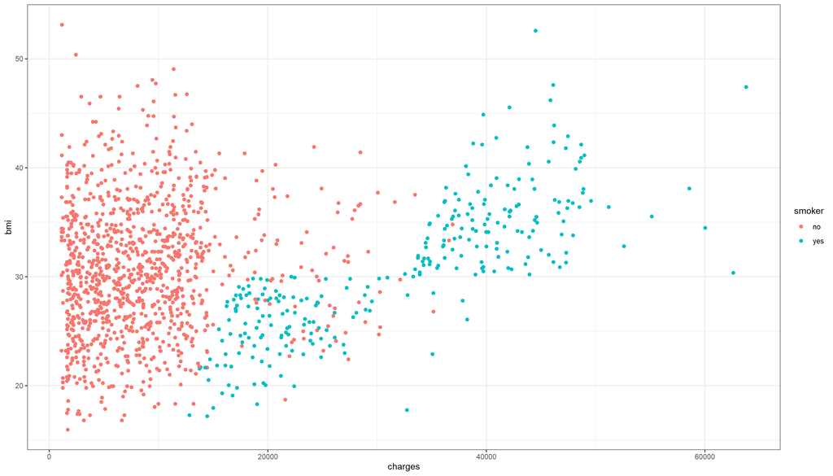

```r
health_insurance %>%
  ggplot(aes(charges, bmi, color = smoker)) +
  geom_point()
```

### Task 3 - Engineer additional features

```r
#your code here
health_insurance <- health_insurance%>%
  mutate(age_bucket = case_when(
    age < 24 ~ 1,
    age <= 36 ~ 2,
    age <= 50 ~ 3,
    age > 50 ~ 4
  ) %>% as.character() %>% fct_infreq(),
  age_household_ratio = (1 + children)/age,
  log_household_size = log(1 + children)
  ) %>%
  select(-children)

health_insurance %>% select(age_bucket, age_household_ratio, log_household_size) %>% summary()
```

```
##  age_bucket age_household_ratio log_household_size
##  3:383      Min.   :0.01562     Min.   :0.0000
##  4:356      1st Qu.:0.03279     1st Qu.:0.0000
##  2:349      Median :0.05263     Median :0.6931
##  1:250      Mean   :0.06014     Mean   :0.5818
##             3rd Qu.:0.07692     3rd Qu.:1.0986
##             Max.   :0.31579     Max.   :1.7918
```

```r
health_insurance %>% count(age_bucket) %>% make_table
```

| age_bucket | n |
| --- | --- |
| 3 | 383 |
| 4 | 356 |
| 2 | 349 |
| 1 | 250 |

```r
#Base R solution

#See documentation of ?cut
#health_insurance$age_bucket2 <- cut(x = health_insurance$age, breaks = c(0,23, 36, 50, 500))

#table(health_insurance$age_bucket2)
```

### Task 4 - Hierarchical Clustering

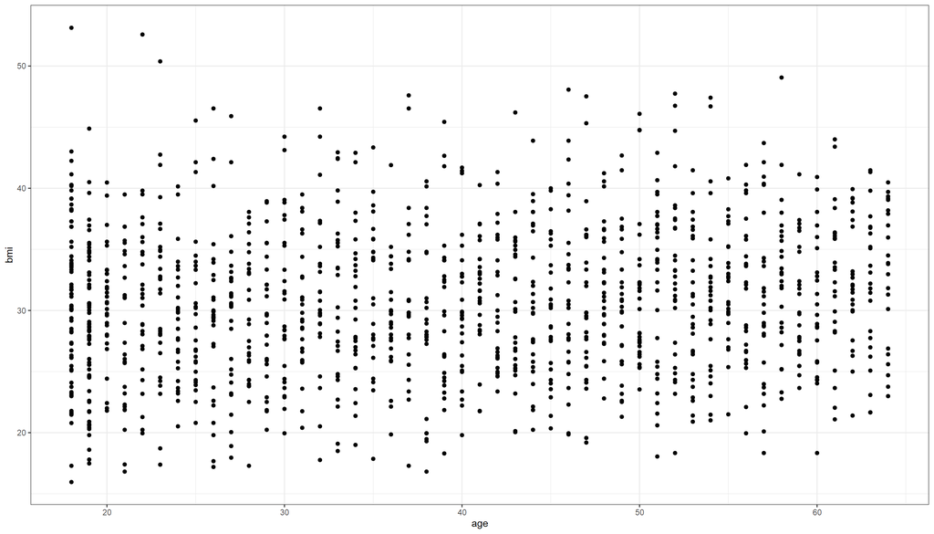

```r
health_insurance %>% ggplot(aes(age, bmi)) + geom_point()
```

```r
health_insurance %>% summary()
```

```
##       age            sex           bmi        smoker           region
##  Min.   :18.00   male  :676   Min.   :15.96   no :1064   southeast:364
##  1st Qu.:27.00   female:662   1st Qu.:26.30   yes: 274   northwest:325
##  Median :39.00                Median :30.40              southwest:325
##  Mean   :39.21                Mean   :30.66              northeast:324
##  3rd Qu.:51.00                3rd Qu.:34.69
##  Max.   :64.00                Max.   :53.13
##     charges      age_bucket age_household_ratio log_household_size
##  Min.   : 1122   3:383      Min.   :0.01562     Min.   :0.0000
##  1st Qu.: 4740   4:356      1st Qu.:0.03279     1st Qu.:0.0000
##  Median : 9382   2:349      Median :0.05263     Median :0.6931
##  Mean   :13270   1:250      Mean   :0.06014     Mean   :0.5818
##  3rd Qu.:16640              3rd Qu.:0.07692     3rd Qu.:1.0986
##  Max.   :63770              Max.   :0.31579     Max.   :1.7918
```

```r
#euclidean distance example
x0 <- 40
y0 <- 40

x1 <- 60
y1 <- 50

sqrt(sum())
```

```
## [1] 0
```

```r
sqrt((40 - 60)^2 + (40-50)^2)
```

```
## [1] 22.36068
```

```r
age <- health_insurance$age[1:50]
bmi <- health_insurance$bmi[1:50]

#your code here
#apply scaling
#(no code is provided)
age <- (age - mean(age))/sd(age)
bmi <- (bmi - mean(bmi))/sd(bmi)

summary(age)
```

```
##    Min. 1st Qu.  Median    Mean 3rd Qu.    Max.
## -1.2332 -0.8250 -0.2861  0.0000  1.1346  1.7061
```

```r
summary(bmi)
```

```
##     Min.  1st Qu.   Median     Mean  3rd Qu.     Max.
## -2.27056 -0.76577  0.08931  0.00000  0.79263  1.90797
```

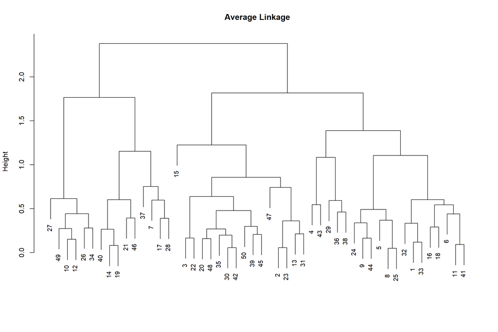

```r
#put age and bmi into a matrix
x <- as.matrix(tibble(age = age, bmi = bmi))

#perform hiearchical clustering
hc_average = hclust(dist(x), method = "average")

#plot the dedgrogram
plot(hc_average, main = "Average Linkage", xlab = "", sub = "", cex = .9)
```

Select which clustering method to use as well as the number of clusters.

```r
#make a selection
selected_height = 1
```

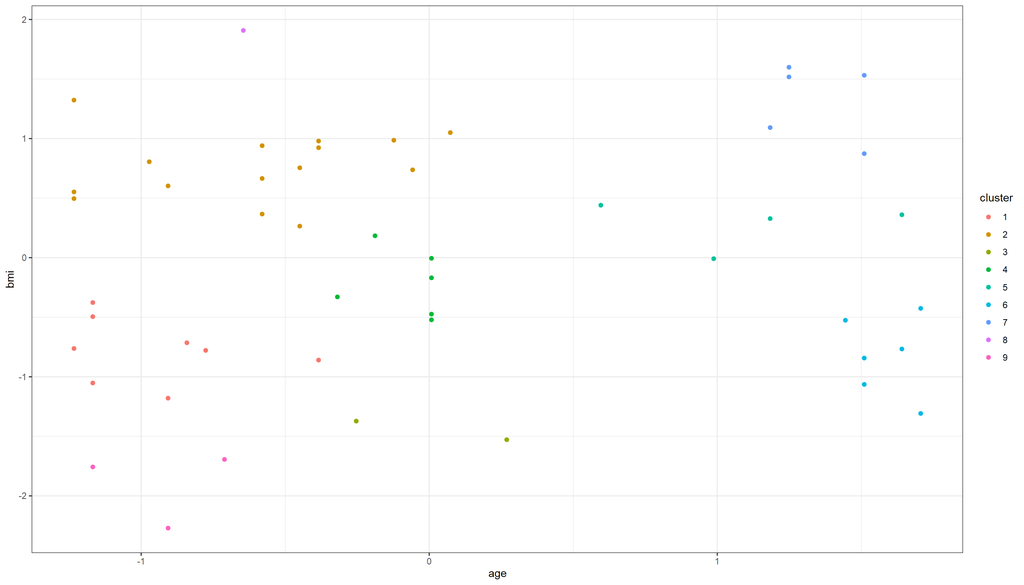

```r
cluster_data <- tibble(age = age, bmi = bmi) %>%
  mutate(cluster = as.factor(cutree(hc_average,h= selected_height)))

cluster_data %>%
  ggplot(aes(age, bmi, color = cluster)) +
  geom_point()
```

### Task 5 - Select an Interaction

```r
#example of a formula using all variables + an interaction between age and sex
glm_formula = charges ~ age + sex + bmi + smoker + region + age_bucket + age_household_ratio + log_household_size + age*sex

glm_formula = charges ~ age + sex + bmi + smoker + region  + age_bucket + age_household_ratio + log_household_size + bmi*smoker
```

### Task 6 - Fit two GLMs

```r
#create a train/test split
index <- createDataPartition(y = health_insurance$charges, list = F, p = 0.8) %>% as.numeric()
train <-  health_insurance[index,]
test <- health_insurance[-index,]

nrow(train) + nrow(test) == nrow(health_insurance)
```

```
## [1] TRUE
```

```r
nrow(train)/nrow(health_insurance)
```

```
## [1] 0.8011958
```

```r
#your assistant has provided you with these functions
#no changes need to be made
mae <- function(y, y_hat){
  mean(abs(y - y_hat))
}

fit_glm <- function(family_link = gaussian(link = "identity")){
  model = glm(formula = glm_formula,
            family = family_link,
            data = train)
  pred = predict(model, test, type = "response")
  paste0(
    "family:", model$family$family, ", ",
    "link:", model$family$link, ", ",
    "test mae:", round(mae(pred, test$charges),0))
}
```

For example, to fit a GLM with a Gaussian response and a log link, use

```r
fit_glm(gaussian(link = "log"))
```

```
## [1] "family:gaussian, link:log, test mae:3958"
```

```r
fit_glm(gaussian(link = "identity"))
```

```
## [1] "family:gaussian, link:identity, test mae:3010"
```

```r
fit_glm(gaussian(link = "log"))
```

```
## [1] "family:gaussian, link:log, test mae:3958"
```

```r
fit_glm(gaussian(link = "sqrt"))
```

```
## [1] "family:gaussian, link:sqrt, test mae:3304"
```

```r
fit_glm(gaussian(link = "1/mu^2"))
```

```
## [1] "family:gaussian, link:1/mu^2, test mae:5134"
```

```r
fit_glm(gaussian(link = "inverse"))
```

```
## [1] "family:gaussian, link:inverse, test mae:4824"
```

```r
fit_glm(Gamma(link = "identity"))
```

```
## [1] "family:Gamma, link:identity, test mae:3020"
```

```r
fit_glm(Gamma(link = "log"))
```

```
## [1] "family:Gamma, link:log, test mae:4238"
```

```r
fit_glm(Gamma(link = "sqrt"))
```

```
## [1] "family:Gamma, link:sqrt, test mae:3328"
```

```r
fit_glm(Gamma(link = "1/mu^2"))
```

```
## [1] "family:Gamma, link:1/mu^2, test mae:5086"
```

```r
fit_glm(Gamma(link = "inverse"))
```

```
## [1] "family:Gamma, link:inverse, test mae:5142"
```

```r
fit_glm(inverse.gaussian(link = "identity"))
```

```
## [1] "family:inverse.gaussian, link:identity, test mae:3063"
```

```r
fit_glm(inverse.gaussian(link = "log"))
```

```
## [1] "family:inverse.gaussian, link:log, test mae:7298"
```

```r
fit_glm(inverse.gaussian(link = "sqrt"))
```

```
## [1] "family:inverse.gaussian, link:sqrt, test mae:3764"
```

```r
#fit_glm(inverse.gaussian(link = "1/mu^2"))
#fit_glm(inverse.gaussian(link = "inverse"))
```

To find the possible families, see `?family`.

The possible link functions are `logit`, `probit`, `cauchit`, `cloglog`, `identity`, `log`, `sqrt`, `1/mu^2`, and `inverse`.

### Task 7 - Compare the two models

### Task 8 - Examine the residual plots

```r
#change the family and link to the model that you choose
model = glm(formula = glm_formula,
            family = Gamma(link = "identity"),
            data = train)

pred = predict(model, test, type = "response")
mae(pred, test$charges)
```

```
## [1] 3020.495
```

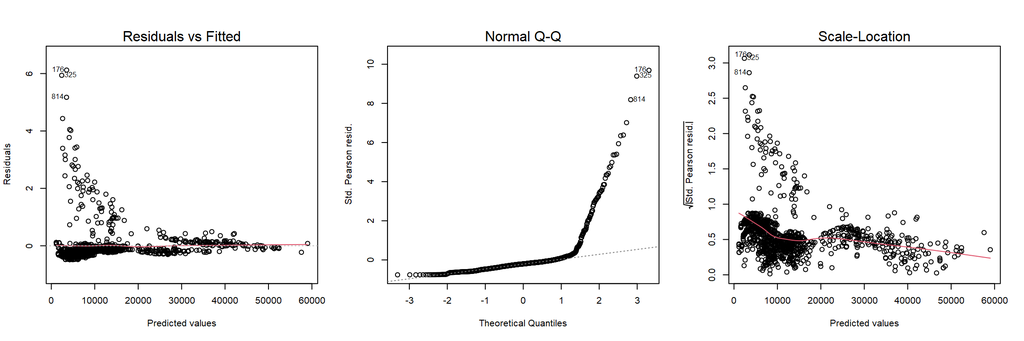

```r
par(mfrow = c(1,3))
plot(model, which = c(1,2,3))
```

```r
summary(model)
```

```
##
## Call:
## glm(formula = glm_formula, family = Gamma(link = "identity"),
##     data = train)
##
## Deviance Residuals:
##      Min        1Q    Median        3Q       Max
## -0.59471  -0.26567  -0.13506  -0.02907   2.88365
##
## Coefficients:
##                       Estimate Std. Error t value Pr(>|t|)
## (Intercept)          -5436.402   2067.159  -2.630 0.008665 **
## age                    277.884     45.854   6.060 1.89e-09 ***
## sexfemale              984.156    227.827   4.320 1.71e-05 ***
## bmi                     -2.652     17.622  -0.150 0.880416
## smokeryes           -18262.297   5297.465  -3.447 0.000588 ***
## regionnorthwest        561.063    333.775   1.681 0.093065 .
## regionsouthwest       -741.390    276.230  -2.684 0.007389 **
## regionnortheast       1604.806    396.377   4.049 5.53e-05 ***
## age_bucket4           1573.402    901.929   1.744 0.081365 .
## age_bucket2            950.095    749.048   1.268 0.204933
## age_bucket1           1597.148   1043.806   1.530 0.126286
## age_household_ratio  10004.472  10041.394   0.996 0.319321
## log_household_size     887.735    776.417   1.143 0.253142
## bmi:smokeryes         1372.899    192.378   7.136 1.78e-12 ***
## ---
## Signif. codes:  0 '***' 0.001 '**' 0.01 '*' 0.05 '.' 0.1 ' ' 1
##
## (Dispersion parameter for Gamma family taken to be 0.4107704)
##
##     Null deviance: 846.48  on 1071  degrees of freedom
## Residual deviance: 196.47  on 1058  degrees of freedom
## AIC: 20813
##
## Number of Fisher Scoring iterations: 9
```

### Task 9 - Fit a GBM

Your assistant has already run cross-validation to find the best set of hyperparameters. This is

n.trees interaction.depth shrinkage n.minobsinnode 1000 3 0.01 30

```r
#no changes are needed to this code

#look at many different parameter combinations
tunegrid <- expand.grid(
    interaction.depth = c(3),
    n.trees = c(1000),
    shrinkage = c(0.01),
    n.minobsinnode = c(30)
    )

#use the mae as the evaluation metric
mae_summary <- function (data,
                        lev = NULL,
                        model = NULL) {
      out <- mae(data$obs, data$pred)
      names(out) <- "mae"
      out
}

#use 3-fold cross validation
control <- trainControl(
  summaryFunction = mae_summary,
  method='repeatedcv',
  number=3,
  p = 0.8)

#fit a GBM using MAE as the error metric
gbm <- train(charges ~ .,
            data = train,
            method='gbm',
            tuneGrid=tunegrid,
            metric = "mae",
            maximize = FALSE,
            trControl=control,
            verbose = FALSE
            )
```

### Task 10 - Validate the GBM

```r
#get the mae on the test set
pred = predict(gbm, test)
mae(pred, test$charges)
```

```
## [1] 2561.862
```

### Task 11 - Interpret the GBM

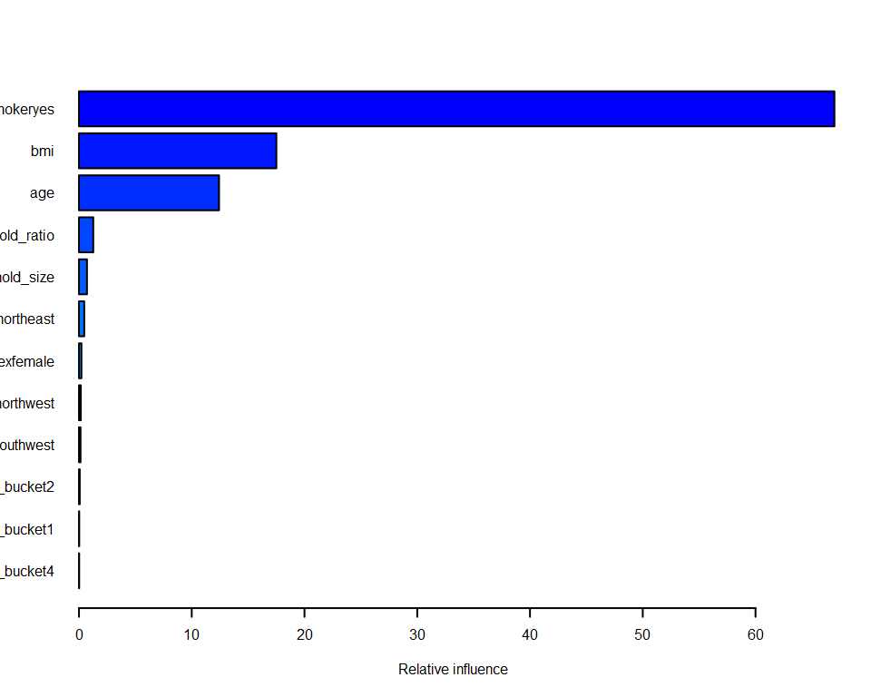

```
##                                     var     rel.inf
## smokeryes                     smokeryes 66.99822391
## bmi                                 bmi 17.50618627
## age                                 age 12.42153060
## age_household_ratio age_household_ratio  1.26698554
## log_household_size   log_household_size  0.70963163
## regionnortheast         regionnortheast  0.46685191
## sexfemale                     sexfemale  0.22008092
## regionnorthwest         regionnorthwest  0.16355836
## regionsouthwest         regionsouthwest  0.13814228
## age_bucket2                 age_bucket2  0.06891267
## age_bucket1                 age_bucket1  0.02237732
## age_bucket4                 age_bucket4  0.01751858
```

```r
par(las = 1, cex = 0.5)
summary(gbm)
```

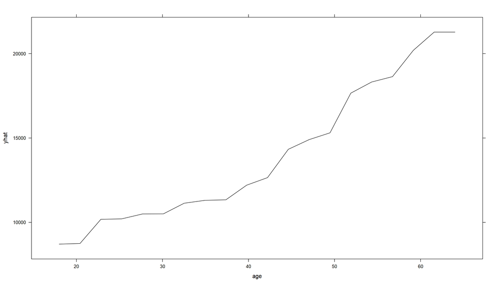

```r
pdp::partial(gbm, pred.var = "age", grid.resolution = 20, plot = T)
```

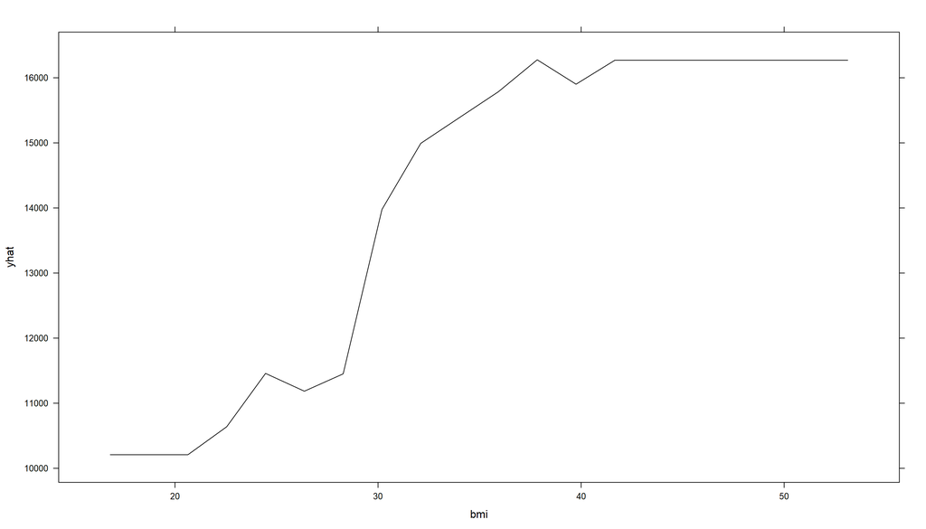

```r
pdp::partial(gbm, pred.var = "bmi", grid.resolution = 20, plot = T)
```

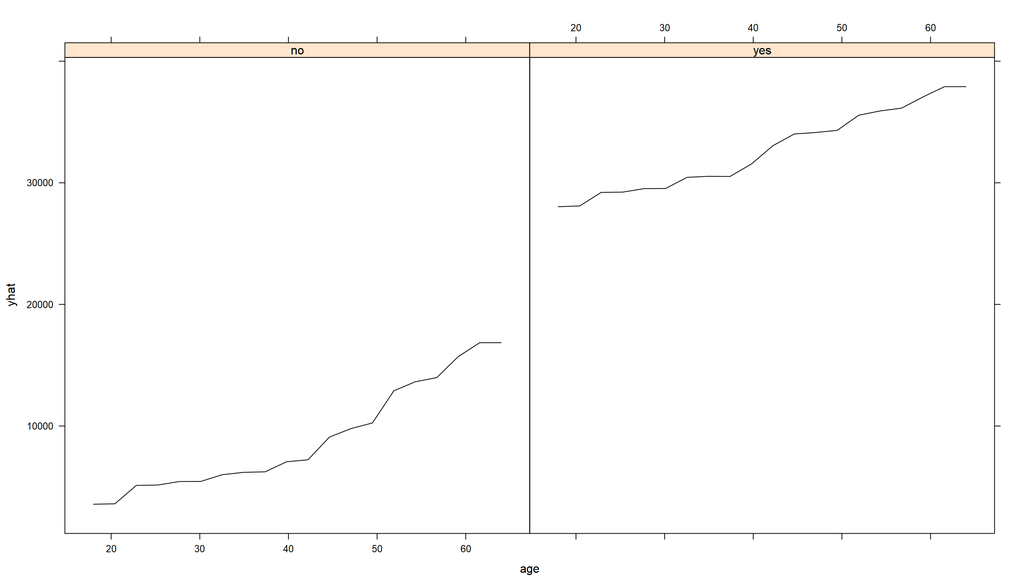

```r
pdp::partial(gbm, pred.var = c("smoker", "age"), grid.resolution = 20, plot = T)
```

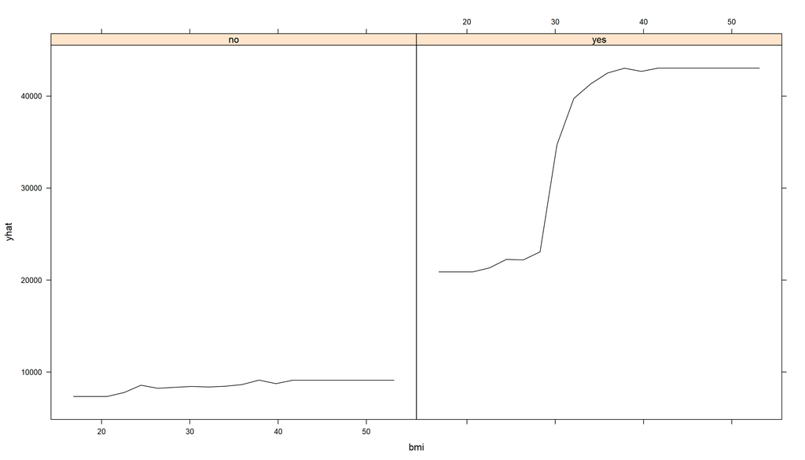

```r
pdp::partial(gbm, pred.var = c("smoker", "bmi"), grid.resolution = 20, plot = T)
```

### Task 12 - Executive Summary

Write in the Word template.